# Course Evaluations Analysis

Ananya Iyer (ai6792)

2025-01-28

# **Problem 1: Beauty, or not, in the classroom**

```
## 'data.frame':    463 obs. of  12 variables:
##  $ minority   : chr  "yes" "no" "no" "no" ...
##  $ age        : int  36 59 51 40 31 62 33 51 33 47 ...
##  $ gender     : chr  "female" "male" "male" "female" ...
##  $ credits    : chr  "more" "more" "more" "more" ...
##  $ beauty     : num  0.29 -0.738 -0.572 -0.678 1.51 ...
##  $ eval       : num  4.3 4.5 3.7 4.3 4.4 4.2 4 3.4 4.5 3.9 ...
##  $ division   : chr  "upper" "upper" "upper" "upper" ...
##  $ native     : chr  "yes" "yes" "yes" "yes" ...
##  $ tenure     : chr  "yes" "yes" "yes" "yes" ...
##  $ students   : int  24 17 55 40 42 182 33 25 48 16 ...
##  $ allstudents: int  43 20 55 46 48 282 41 41 60 19 ...
##  $ prof       : int  1 2 3 4 5 6 7 8 9 10 ...
```

## **Part A**

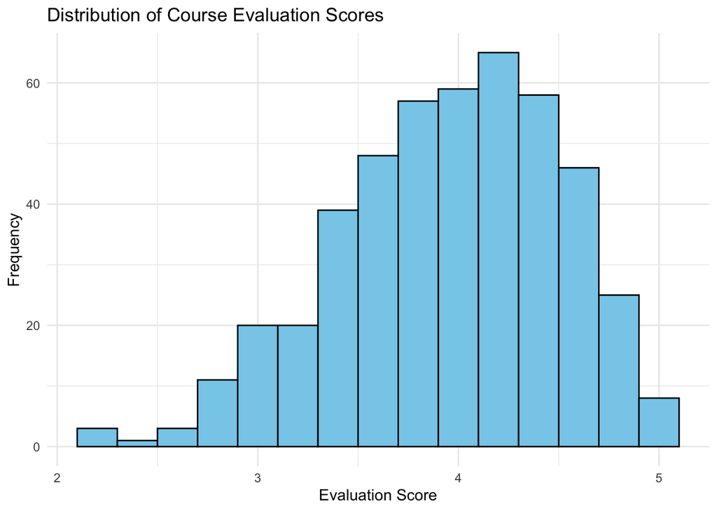

This histogram shows the distribution of course evaluation scores, which are concentrated between 3 and 5, with a peak around 4. The majority of courses are rated highly, indicating overall positive evaluations.

## **Part B**

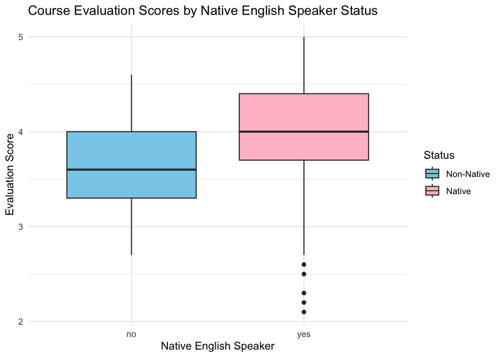

## **Part C**

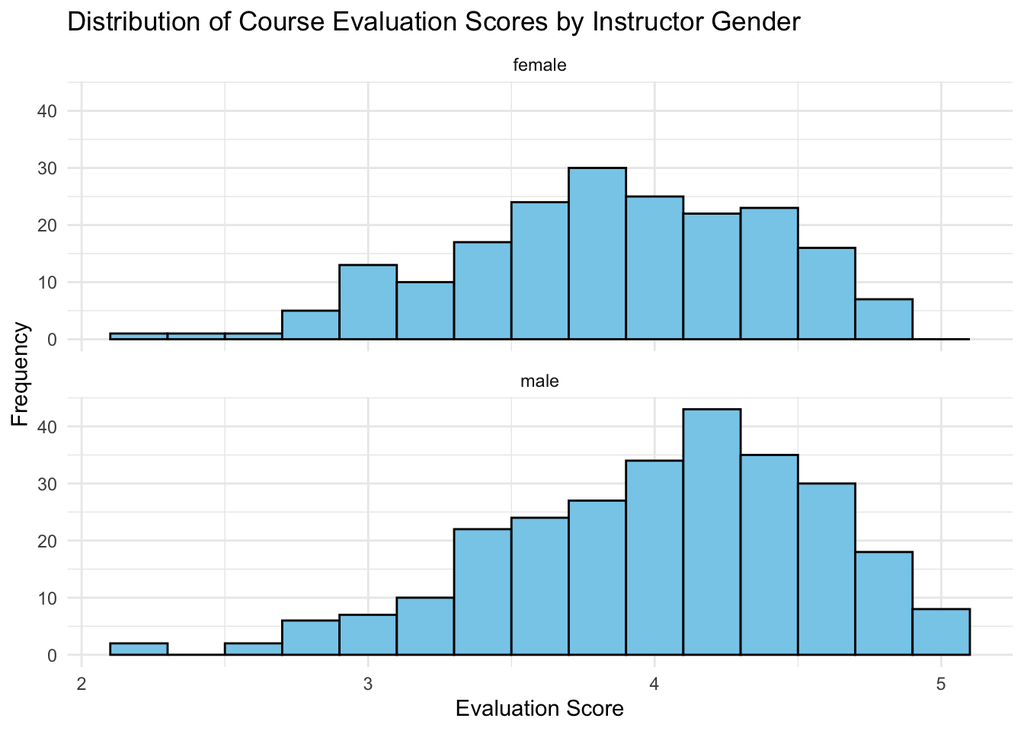

This faceted histogram compares the distribution of course evaluation scores for male and female instructors. Both distributions are left skewed, with male instructors showing a slightly higher proportion of scores near the maximum of 5, though the differences are small.

## **Part D**

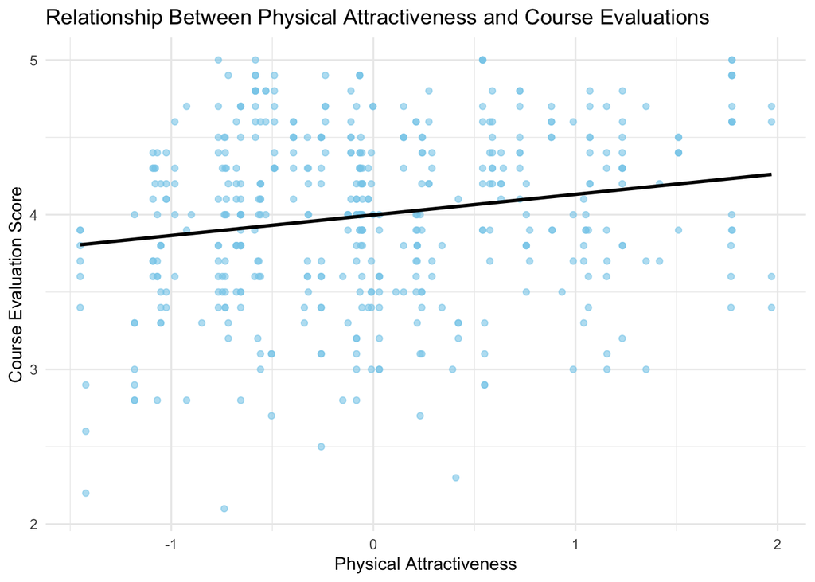

This scatterplot examines the relationship between professors’ physical attractiveness (x-axis) and their course evaluation scores (y-axis). There is a weak positive relationship suggests that higher attractiveness ratings correlate with better course evaluations.

# **Problem 2: bike sharing**

## **Plot A**

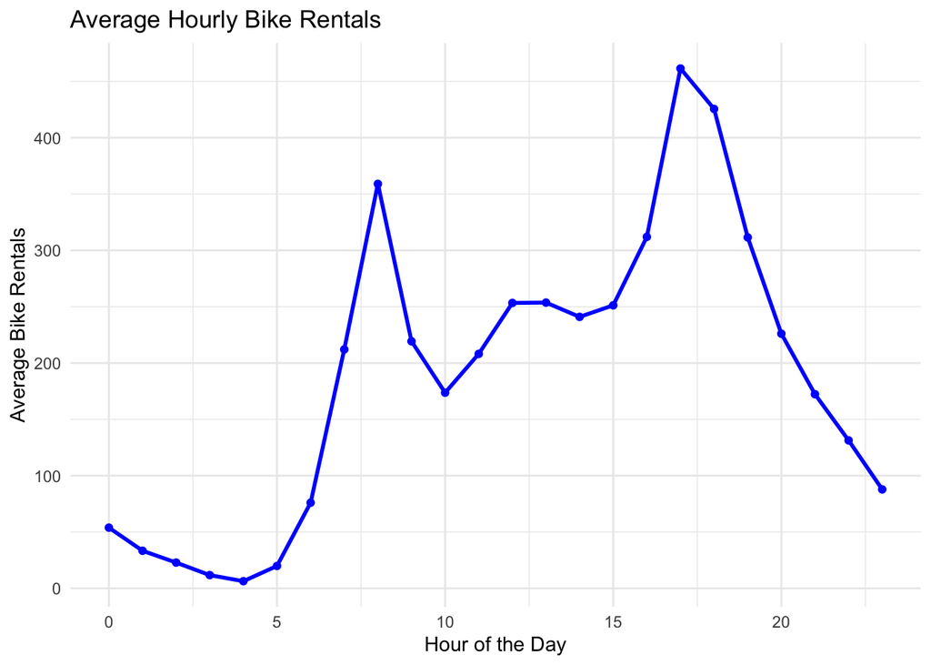

This line graph displays the average number of bike rentals for each hour of the day, aggregated across all days in the dataset. The x-axis represents the hour of the day in 24-hour format and the y-axis indicates the average bike rentals. Ridership peaks at 8 AM and again between 5-6 PM, corresponding to typical work commuting hours. This suggests the bike-sharing system is heavily used for work-related travel during weekdays.

## **Plot B**

[output not shown]

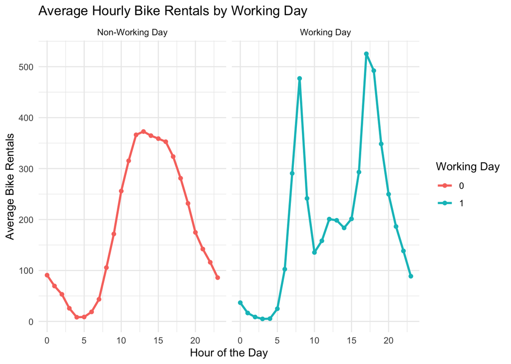

This faceted line graph compares average hourly bike rentals for working days and non-working days. The x-axis shows the hour of the day in 24-hour format, and the y-axis represents the average number of rentals. On working days, ridership spikes during morning (8 AM) and evening (5-6 PM) work commuting hours, while on non-working days, demand peaks around noon.

## **Plot C**

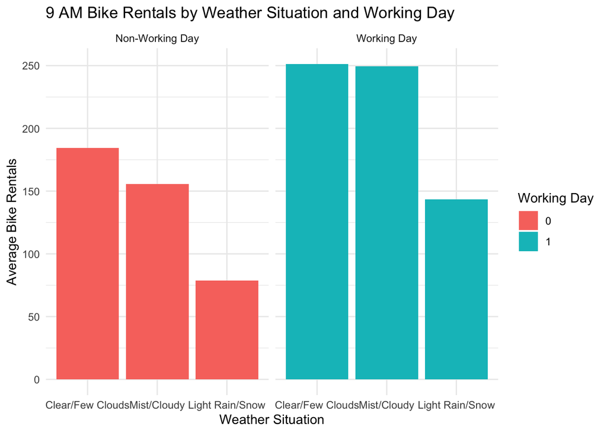

This plot shows how weather and workday status affect bike rentals at 9 AM. The x-axis categorizes weather conditions, and the y-axis measures average bike rentals. Clear weather days have a higher amount of rentals, on both workdays and non-working days.

# **Problem 3: Capital Metro UT Ridership*

## **Part 1**

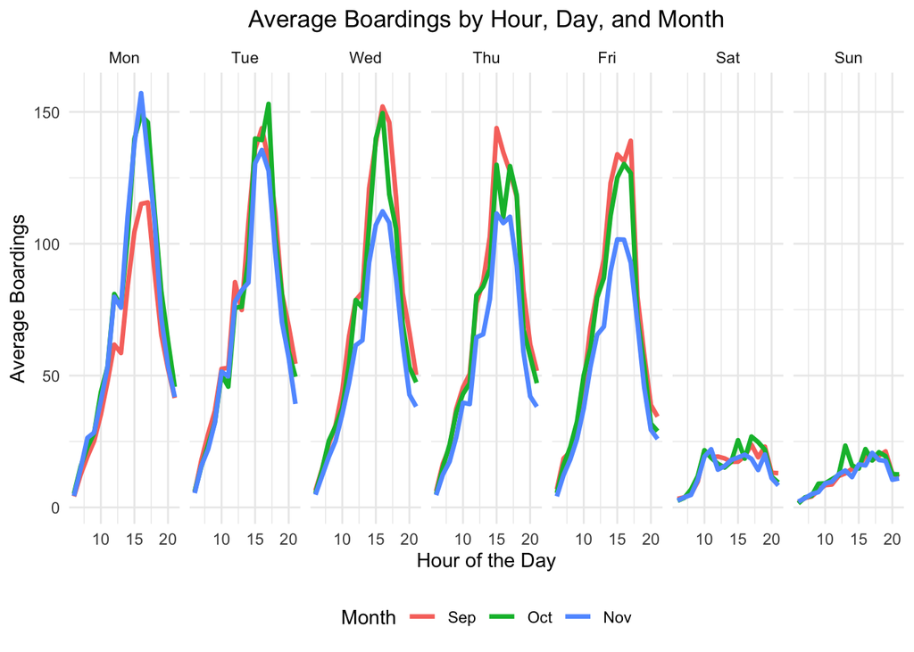

## **Part 2**

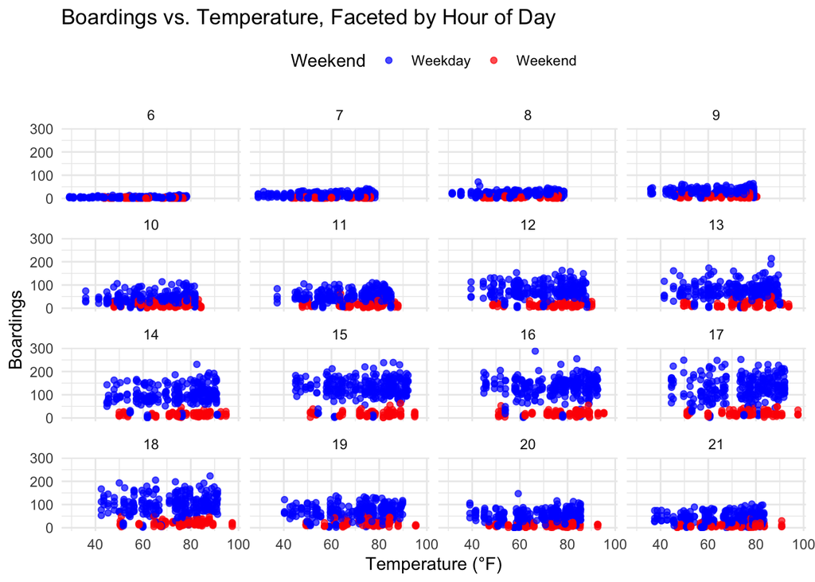

This figure displays the relationship between Capital Metro bus boardings and temperature for University of Texas students. Each panel represents a specific hour of the day, with blue dots representing weekday boardings and red dots representing weekend boardings. The x-axis shows the temperature in Fahrenheit, and the y-axis shows the number of boardings. In most panels, there’s not a clear peak in ridership at a specific temperature range but most boardings occur between 40 and 90 degrees. The impact of temperature differs between weekdays and weekends. Weekends and weekdays have similar common boarding temperatures, though weekends are a little more spread out later in the day.

# **Problem 4: Wrangling the Billboard Top 100*

## **Part A**

Top 10 Most Popular Songs Since 1958 (Based on Total Weeks on Billboard Top 100)

| Performer | Song | Weeks on Chart |
| --- | --- | --- |
| Imagine Dragons | Radioactive | 87 |
| AWOLNATION | Sail | 79 |
| Jason Mraz | I’m Yours | 76 |
| The Weeknd | Blinding Lights | 76 |
| LeAnn Rimes | How Do I Live | 69 |
| LMFAO Featuring Lauren Bennett & GoonRock | Party Rock Anthem | 68 |
| OneRepublic | Counting Stars | 68 |
| Adele | Rolling In The Deep | 65 |
| Jewel | Foolish Games/You Were Meant For Me | 65 |
| Carrie Underwood | Before He Cheats | 64 |

This table displays the top 10 most popular songs in terms of the total number of weeks they spent on the Billboard Top 100 chart since 1958, up to week 22 of 2021. The table is sorted in descending order of the number of weeks spent on the chart, with “Radioactive” by Imagine Dragons holding the top spot with 87 weeks.

## **Part B**

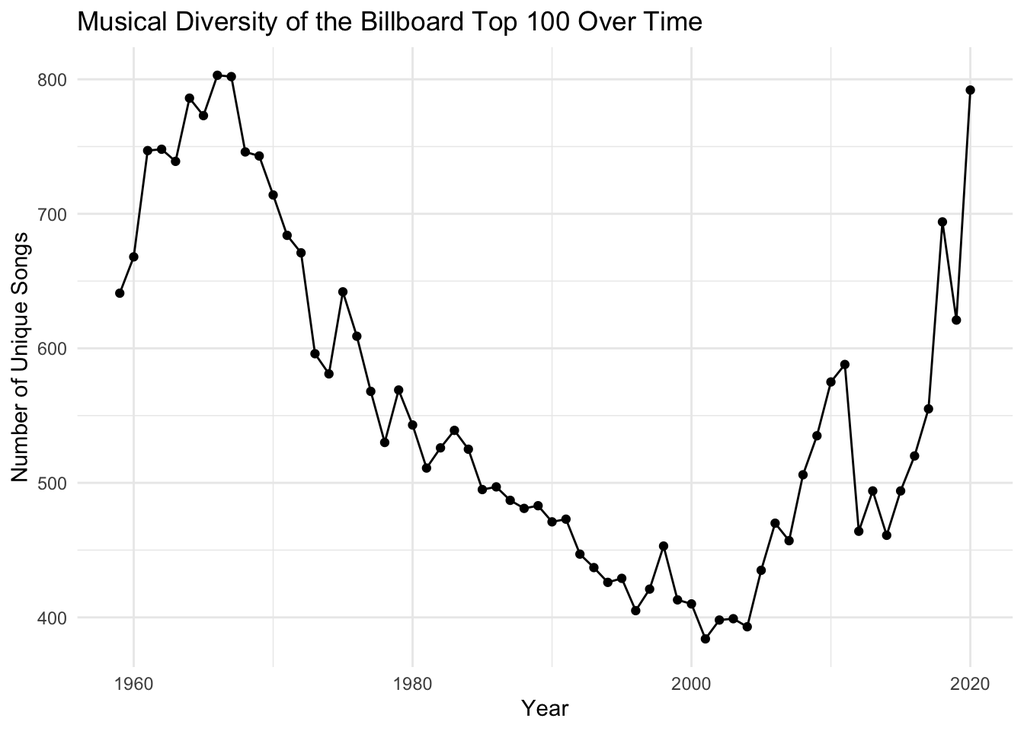

## **Part C**

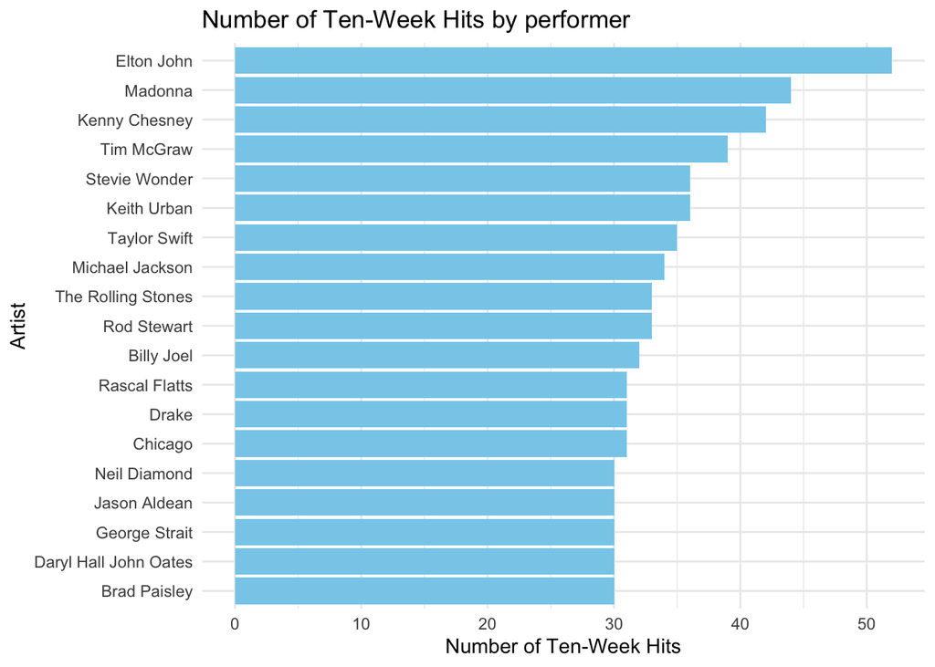

This bar plot presents the 19 artists with the highest number of “ten-week hits” in the Billboard Top 100 since 1958. A “ten-week hit” is defined as a song that has remained on the chart for at least ten consecutive weeks. This plot only considers artists with at least 30 ten-week hits. Elton John tops the list with over 50 ten-week hits, indicating a significant and sustained presence on the chart. The list includes artists from various genres, including pop, country, and rock.